# Canada

Grupo: Americo Freitas, Arleks dos Santos e Luciano Ozorio

2022-05-04

## Importanto a base

Como a primeira coluna, referente ao ano (…1) é descritiva, estamos retirando da base.

```r
library(readxl)
xlsfile <- file.path('/cloud/project','Canada.xlsx')
df <- read_xlsx(xlsfile)
df$...1 <- NULL
```

## Seleção de variáveis

Ao fazer o summary, eu reparei que as variáveis **EXGR_INTDVAPSH, EXGRPSH, EXGR_DVAPSH, IMGRPSH, FFD_DVAPSH, DFD_FVAPSH, FD_VASH, CONS_VASH, GFCF_VASH** sempre tem o mesmo valor, então elas já podem ser descartadas da seleção de variáveis.

```r
summary(df)
```

```
##       EXGR           EXGR_FNL         EXGR_INT         EXGR_DVA
##  Min.   :211974   Min.   : 84451   Min.   :127523   Min.   :156207
##  1st Qu.:298183   1st Qu.:122894   1st Qu.:175289   1st Qu.:221262
##  Median :429628   Median :151081   Median :273022   Median :329283
##  Mean   :397406   Mean   :143401   Mean   :254004   Mean   :301488
##  3rd Qu.:495869   3rd Qu.:169087   3rd Qu.:319593   3rd Qu.:376236
##  Max.   :546981   Max.   :183861   Max.   :372224   Max.   :419720
##     EXGR_DDC         EXGR_IDC         EXGR_RIM         EXGR_FVA
##  Min.   :100218   Min.   : 55182   Min.   : 807.2   Min.   : 55767
##  1st Qu.:139389   1st Qu.: 80765   1st Qu.:1078.0   1st Qu.: 76448
##  Median :205694   Median :119353   Median :1377.8   Median : 97806
##  Mean   :190071   Mean   :110028   Mean   :1389.3   Mean   : 95918
##  3rd Qu.:239081   3rd Qu.:139512   3rd Qu.:1684.2   3rd Qu.:117980
##  Max.   :265951   Max.   :152060   Max.   :2126.0   Max.   :129361
##       IMGR           IMGR_FNL         IMGR_INT         IMGR_DVA
##  Min.   :194027   Min.   : 73782   Min.   :120245   Min.   :2255
##  1st Qu.:257286   1st Qu.: 99710   1st Qu.:158064   1st Qu.:3176
##  Median :405444   Median :173061   Median :233981   Median :4823
##  Mean   :394256   Mean   :165140   Mean   :229116   Mean   :4756
##  3rd Qu.:514745   3rd Qu.:221374   3rd Qu.:293371   3rd Qu.:5813
##  Max.   :571391   Max.   :246796   Max.   :326714   Max.   :7775
##      BALGR             REII             PROD              VALU
##  Min.   :-48213   Min.   : 56940   Min.   :1036794   Min.   : 577857
##  1st Qu.:-38326   1st Qu.: 77997   1st Qu.:1343605   1st Qu.: 709673
##  Median : 16031   Median : 99838   Median :2359129   Median :1290798
##  Mean   :  3150   Mean   : 97878   Mean   :2169737   Mean   :1181006
##  3rd Qu.: 34256   3rd Qu.:120435   3rd Qu.:2836823   3rd Qu.:1558232
##  Max.   : 47846   Max.   :131509   Max.   :3249040   Max.   :1773918
##     FFD_DVA          DFD_FVA          BALVAFD           FD_VA
##  Min.   :153952   Min.   :136006   Min.   :-48213   Min.   : 559911
##  1st Qu.:218086   1st Qu.:177422   1st Qu.:-38326   1st Qu.: 663028
##  Median :324460   Median :308675   Median : 16031   Median :1285771
##  Mean   :296731   Mean   :293582   Mean   :  3150   Mean   :1177856
##  3rd Qu.:370262   3rd Qu.:389780   3rd Qu.: 34256   3rd Qu.:1600359
##  Max.   :411945   Max.   :441505   Max.   : 47846   Max.   :1813438
##     CONS_VA           GFCF_VA         EXGR_DVASH      EXGR_FVASH
##  Min.   : 435755   Min.   :107036   Min.   :72.10   Min.   :21.61
##  1st Qu.: 509853   1st Qu.:142846   1st Qu.:74.20   1st Qu.:23.09
##  Median : 957964   Median :294601   Median :75.78   Median :24.21
##  Mean   : 881135   Mean   :267298   Mean   :75.53   Mean   :24.47
```

[output cut: 22 more lines]

```
##  Max.   :51.69   Max.   :1.478   Max.   :100   Max.   :100   Max.   :100
##   VALU_FFDDVA      PROD_VASH        FD_VASH      CONS_VASH     GFCF_VASH
##  Min.   :21.75   Min.   :52.76   Min.   :100   Min.   :100   Min.   :100
##  1st Qu.:23.01   1st Qu.:53.80   1st Qu.:100   1st Qu.:100   1st Qu.:100
##  Median :26.57   Median :54.46   Median :100   Median :100   Median :100
##  Mean   :26.13   Mean   :54.33   Mean   :100   Mean   :100   Mean   :100
##  3rd Qu.:28.35   3rd Qu.:54.74   3rd Qu.:100   3rd Qu.:100   3rd Qu.:100
##  Max.   :32.38   Max.   :55.73   Max.   :100   Max.   :100   Max.   :100
##    DEXFVAPSH       FEXDVAPSH
##  Min.   :21.61   Min.   : 9.512
##  1st Qu.:23.09   1st Qu.:10.313
##  Median :24.21   Median :13.261
##  Mean   :24.47   Mean   :12.811
##  3rd Qu.:25.80   3rd Qu.:14.865
##  Max.   :27.89   Max.   :16.999
```

Removendo as variáveis com valor constante do dataframe

```r
df$EXGR_INTDVAPSH <- NULL
df$EXGRPSH <- NULL
df$EXGR_DVAPSH <- NULL
df$IMGRPSH <- NULL
df$FFD_DVAPSH <- NULL
df$DFD_FVAPSH <- NULL
df$FD_VASH <- NULL
df$CONS_VASH <- NULL
df$GFCF_VASH <- NULL
```

Analisando a autocorrelação das variáveis

```r
cor(df)
```

```
##                        EXGR    EXGR_FNL    EXGR_INT    EXGR_DVA   EXGR_DDC
## EXGR             1.00000000  0.96338500  0.99552221  0.99821975  0.9952920
## EXGR_FNL         0.96338500  1.00000000  0.93372615  0.95088801  0.9425997
## EXGR_INT         0.99552221  0.93372615  1.00000000  0.99755116  0.9965642
## EXGR_DVA         0.99821975  0.95088801  0.99755116  1.00000000  0.9986876
## EXGR_DDC         0.99529203  0.94259973  0.99656424  0.99868758  1.0000000
## EXGR_IDC         0.99707451  0.95911683  0.99312095  0.99615182  0.9903587
## EXGR_RIM         0.91297677  0.84748881  0.92019139  0.91711488  0.9300919
## EXGR_FVA         0.97446155  0.97937508  0.95578666  0.95933357  0.9504187
## IMGR             0.97835311  0.93287194  0.97737749  0.97278385  0.9636471
## IMGR_FNL         0.96634887  0.90889130  0.96980431  0.96250587  0.9532492
## IMGR_INT         0.98419610  0.94928177  0.97939348  0.97715998  0.9681693
## IMGR_DVA         0.95294359  0.85676681  0.97028281  0.96227830  0.9700426
## BALGR           -0.61346814 -0.55414682 -0.62371600 -0.59776961 -0.5720373
## REII             0.97554158  0.97916124  0.95730407  0.96070345  0.9521910
## PROD             0.97617461  0.91666407  0.98018299  0.97620643  0.9681942
## VALU             0.97179685  0.90867036  0.97715616  0.97218544  0.9640541
## FFD_DVA          0.99835571  0.95202330  0.99733243  0.99998560  0.9984952
## DFD_FVA          0.97028517  0.91542584  0.97275615  0.96654836  0.9571929
## BALVAFD         -0.61346814 -0.55414682 -0.62371600 -0.59776961 -0.5720373
## FD_VA            0.96121838  0.89731072  0.96703702  0.96040041  0.9508042
## CONS_VA          0.95629545  0.89594515  0.96094553  0.95484931  0.9441248
## GFCF_VA          0.96912158  0.89835466  0.97722109  0.97011291  0.9629762
## EXGR_DVASH       0.67825822  0.54877343  0.71211620  0.71925804  0.7306977
## EXGR_FVASH      -0.67825822 -0.54877343 -0.71211620 -0.71925804 -0.7306977
## EXGR_DVAFXSH     0.92604788  0.80657499  0.95206788  0.93347343  0.9338344
## EXGR_FNLDVASH   -0.89709372 -0.75036820 -0.93322521 -0.91159277 -0.9167279
## EXGR_INTDVASH    0.84987405  0.70205115  0.88721341  0.87781180  0.8862727
## EXGR_TDVAIND     0.67825822  0.54877343  0.71211620  0.71925804  0.7306977
## EXGR_TFVAIND    -0.67825822 -0.54877343 -0.71211620 -0.71925804 -0.7306977
## EXGR_SERV_DVASH  0.74690793  0.74732320  0.73377526  0.74011737  0.7131583
## EXGR_SERV_FVASH -0.25278085 -0.07372279 -0.31151379 -0.30783164 -0.3377423
## IMGRINT_REII    -0.83351420 -0.72652819 -0.85674069 -0.84992485 -0.8412193
## IMGR_DVASH       0.05804516 -0.04408965  0.09304425  0.09144961  0.1325522
## VALU_FFDDVA     -0.71143637 -0.61631989 -0.73260068 -0.71547933 -0.6954071
## PROD_VASH        0.21981080  0.05808079  0.27300780  0.23510260  0.2274452
## DEXFVAPSH       -0.67790626 -0.54828421 -0.71181876 -0.71893654 -0.7304155
## FEXDVAPSH        0.92601898  0.80647878  0.95206321  0.93346139  0.9338595
##                    EXGR_IDC    EXGR_RIM    EXGR_FVA       IMGR   IMGR_FNL
## EXGR             0.99707451  0.91297677  0.97446155  0.9783531  0.9663489
```

[output cut: 249 more lines]

```
## EXGR_DVASH       -0.5755776  0.31835510 -0.9999986  0.70356598
## EXGR_FVASH        0.5755776 -0.31835510  0.9999986 -0.70356598
## EXGR_DVAFXSH     -0.8236183  0.48881039 -0.7032805  0.99999933
## EXGR_FNLDVASH     0.7604538 -0.45962157  0.7680176 -0.97156898
## EXGR_INTDVASH    -0.7205523  0.42158763 -0.9257718  0.90574066
## EXGR_TDVAIND     -0.5755776  0.31835510 -0.9999986  0.70356598
## EXGR_TFVAIND      0.5755776 -0.31835510  0.9999986 -0.70356598
## EXGR_SERV_DVASH  -0.8907301  0.46069583 -0.5161253  0.72665609
## EXGR_SERV_FVASH   0.1718611 -0.20163027  0.8156591 -0.36875874
## IMGRINT_REII      0.9338240 -0.59127631  0.8119431 -0.89641556
## IMGR_DVASH        0.4053771 -0.36576412 -0.3536144  0.04990577
## VALU_FFDDVA       1.0000000 -0.74398070  0.5753233 -0.82325785
## PROD_VASH        -0.7439807  1.00000000 -0.3187137  0.48865007
## DEXFVAPSH         0.5753233 -0.31871374  1.0000000 -0.70337349
## FEXDVAPSH        -0.8232579  0.48865007 -0.7033735  1.00000000
```

O resultado do sumário abaixo, ficou um pouco inconclusivo. Vou retirar mais algumas variáveis resposta que são autocorrelacionadas e testar novemente.

```r
mod = lm(PROD ~ ., data=df)
summary(mod)
```

```
##
## Call:
## lm(formula = PROD ~ ., data = df)
##
## Residuals:
## ALL 24 residuals are 0: no residual degrees of freedom!
##
## Coefficients: (13 not defined because of singularities)
##                   Estimate Std. Error t value Pr(>|t|)
## (Intercept)      7.098e+06        NaN     NaN      NaN
## EXGR            -1.364e+05        NaN     NaN      NaN
## EXGR_FNL        -1.538e+04        NaN     NaN      NaN
## EXGR_INT        -1.539e+04        NaN     NaN      NaN
## EXGR_DVA        -8.384e+04        NaN     NaN      NaN
## EXGR_DDC        -3.537e+04        NaN     NaN      NaN
## EXGR_IDC        -3.536e+04        NaN     NaN      NaN
## EXGR_RIM        -3.444e+04        NaN     NaN      NaN
## EXGR_FVA        -1.088e+05        NaN     NaN      NaN
## IMGR             2.609e+05        NaN     NaN      NaN
## IMGR_FNL        -4.983e+00        NaN     NaN      NaN
## IMGR_INT                NA         NA      NA       NA
## IMGR_DVA         1.007e+04        NaN     NaN      NaN
## BALGR            2.710e+05        NaN     NaN      NaN
## REII            -4.014e+02        NaN     NaN      NaN
## VALU            -2.352e+00        NaN     NaN      NaN
## FFD_DVA                 NA         NA      NA       NA
## DFD_FVA          1.006e+04        NaN     NaN      NaN
## BALVAFD                 NA         NA      NA       NA
## FD_VA                   NA         NA      NA       NA
## CONS_VA          4.234e+00        NaN     NaN      NaN
## GFCF_VA         -5.428e-01        NaN     NaN      NaN
## EXGR_DVASH       1.204e+06        NaN     NaN      NaN
## EXGR_FVASH              NA         NA      NA       NA
## EXGR_DVAFXSH    -1.621e+04        NaN     NaN      NaN
## EXGR_FNLDVASH   -1.287e+06        NaN     NaN      NaN
## EXGR_INTDVASH   -1.287e+06        NaN     NaN      NaN
## EXGR_TDVAIND            NA         NA      NA       NA
## EXGR_TFVAIND            NA         NA      NA       NA
## EXGR_SERV_DVASH  3.160e+03        NaN     NaN      NaN
## EXGR_SERV_FVASH -1.084e+05        NaN     NaN      NaN
## IMGRINT_REII            NA         NA      NA       NA
## IMGR_DVASH              NA         NA      NA       NA
## VALU_FFDDVA             NA         NA      NA       NA
## PROD_VASH               NA         NA      NA       NA
## DEXFVAPSH               NA         NA      NA       NA
## FEXDVAPSH               NA         NA      NA       NA
##
## Residual standard error: NaN on 0 degrees of freedom
## Multiple R-squared:      1,  Adjusted R-squared:    NaN
## F-statistic:   NaN on 23 and 0 DF,  p-value: NA
```

Restaram as variáveis: **BALGR+REII+VALU+FFD_DVA+DFD_FVA+BALVAFD+FD_VA+CONS_VA+GFCF_VA+EXGR_TDVAIND+EXGR_TFVAIND+EXGR_SERV_DVASH+EXGR_SERV_FVASH+IMGRINT_REII+IMGR_DVASH+VALU_FFDDVA+PROD_VASH+DEXFVAPSH+FEXDVAPSH**.

```r
mod = lm(PROD ~ BALGR+REII+VALU+FFD_DVA+DFD_FVA+BALVAFD+FD_VA+CONS_VA+GFCF_VA+EXGR_TDVAIND+EXGR_TFVAIND+EXGR_SERV_DVASH+EXGR_SERV_FVASH+IMGRINT_REII+IMGR_DVASH+VALU_FFDDVA+PROD_VASH+DEXFVAPSH+FEXDVAPSH, data=df)

summary(mod)
```

```
##
## Call:
## lm(formula = PROD ~ BALGR + REII + VALU + FFD_DVA + DFD_FVA +
##     BALVAFD + FD_VA + CONS_VA + GFCF_VA + EXGR_TDVAIND + EXGR_TFVAIND +
##     EXGR_SERV_DVASH + EXGR_SERV_FVASH + IMGRINT_REII + IMGR_DVASH +
##     VALU_FFDDVA + PROD_VASH + DEXFVAPSH + FEXDVAPSH, data = df)
##
## Residuals:
##     Min      1Q  Median      3Q     Max
## -1407.3  -716.2  -124.3   597.5  1674.6
##
## Coefficients: (3 not defined because of singularities)
##                   Estimate Std. Error t value Pr(>|t|)
## (Intercept)     -2.323e+05  1.691e+07  -0.014  0.98942
## BALGR            2.481e+04  1.233e+04   2.012  0.08417 .
## REII             1.497e+00  6.163e-01   2.430  0.04544 *
## VALU             2.132e+00  1.662e-01  12.823 4.07e-06 ***
## FFD_DVA         -2.481e+04  1.233e+04  -2.012  0.08417 .
## DFD_FVA          2.481e+04  1.233e+04   2.012  0.08417 .
## BALVAFD                 NA         NA      NA       NA
## FD_VA                   NA         NA      NA       NA
## CONS_VA         -5.040e-01  1.613e-01  -3.124  0.01675 *
## GFCF_VA         -1.524e-01  1.420e-01  -1.073  0.31874
## EXGR_TDVAIND     2.186e+04  1.692e+05   0.129  0.90085
## EXGR_TFVAIND            NA         NA      NA       NA
## EXGR_SERV_DVASH -1.448e+03  1.243e+03  -1.165  0.28219
## EXGR_SERV_FVASH -8.406e+03  2.776e+03  -3.029  0.01915 *
## IMGRINT_REII     3.457e+03  1.349e+03   2.562  0.03746 *
## IMGR_DVASH      -2.640e+04  1.914e+04  -1.379  0.21026
## VALU_FFDDVA     -9.159e+03  2.015e+03  -4.545  0.00265 **
## PROD_VASH       -2.839e+04  2.503e+03 -11.342 9.27e-06 ***
## DEXFVAPSH        1.688e+04  1.692e+05   0.100  0.92334
## FEXDVAPSH       -4.691e+03  1.410e+03  -3.326  0.01265 *
## ---
## Signif. codes:  0 '***' 0.001 '**' 0.01 '*' 0.05 '.' 0.1 ' ' 1
##
## Residual standard error: 1586 on 7 degrees of freedom
## Multiple R-squared:      1,  Adjusted R-squared:      1
## F-statistic: 3.737e+05 on 16 and 7 DF,  p-value: < 2.2e-16
```

Fazendo a seleção da melhor combinação de variáveis possível com o step, o melhor resultado foi a combinação das variáveis:

**lm(formula = PROD ~ BALGR+REII+VALU+FFD_DVA+DFD_FVA+CONS_VA+GFCF_VA+EXGR_TDVAIND+EXGR_SERV_DVASH+EXGR_SERV_FVASH+IMGRINT_REII+IMGR_DVASH+VALU_FFDDVA+PROD_VASH+FEXDVAPSH, data = df)**

```r
mod2=step(mod, direction = "backward")
```

```
## Start:  AIC=358.14
## PROD ~ BALGR + REII + VALU + FFD_DVA + DFD_FVA + BALVAFD + FD_VA +
##     CONS_VA + GFCF_VA + EXGR_TDVAIND + EXGR_TFVAIND + EXGR_SERV_DVASH +
##     EXGR_SERV_FVASH + IMGRINT_REII + IMGR_DVASH + VALU_FFDDVA +
##     PROD_VASH + DEXFVAPSH + FEXDVAPSH
##
##
## Step:  AIC=358.14
## PROD ~ BALGR + REII + VALU + FFD_DVA + DFD_FVA + BALVAFD + FD_VA +
##     CONS_VA + GFCF_VA + EXGR_TDVAIND + EXGR_SERV_DVASH + EXGR_SERV_FVASH +
##     IMGRINT_REII + IMGR_DVASH + VALU_FFDDVA + PROD_VASH + DEXFVAPSH +
##     FEXDVAPSH
##
##
## Step:  AIC=358.14
## PROD ~ BALGR + REII + VALU + FFD_DVA + DFD_FVA + BALVAFD + CONS_VA +
##     GFCF_VA + EXGR_TDVAIND + EXGR_SERV_DVASH + EXGR_SERV_FVASH +
##     IMGRINT_REII + IMGR_DVASH + VALU_FFDDVA + PROD_VASH + DEXFVAPSH +
##     FEXDVAPSH
##
##
## Step:  AIC=358.14
## PROD ~ BALGR + REII + VALU + FFD_DVA + DFD_FVA + CONS_VA + GFCF_VA +
##     EXGR_TDVAIND + EXGR_SERV_DVASH + EXGR_SERV_FVASH + IMGRINT_REII +
##     IMGR_DVASH + VALU_FFDDVA + PROD_VASH + DEXFVAPSH + FEXDVAPSH
##
##                   Df Sum of Sq       RSS    AIC
## - DEXFVAPSH        1     25031  17636709 356.18
## - EXGR_TDVAIND     1     41983  17653660 356.20
## <none>                          17611677 358.14
## - GFCF_VA          1   2898218  20509895 359.80
## - EXGR_SERV_DVASH  1   3414478  21026156 360.40
## - IMGR_DVASH       1   4786317  22397995 361.91
## - BALGR            1  10180442  27792119 367.09
## - FFD_DVA          1  10180790  27792467 367.09
## - DFD_FVA          1  10180795  27792473 367.09
## - REII             1  14853524  32465201 370.82
## - IMGRINT_REII     1  16509716  34121393 372.02
## - EXGR_SERV_FVASH  1  23076912  40688589 376.24
## - CONS_VA          1  24553434  42165111 377.10
```

[output cut: 12 more lines]

```
## - GFCF_VA          1   2912984  20549692 357.85
## - EXGR_SERV_DVASH  1   3396400  21033109 358.41
## - IMGR_DVASH       1   5202372  22839080 360.38
## - EXGR_TDVAIND     1   5772101  23408809 360.97
## - BALGR            1  12869586  30506294 367.33
## - DFD_FVA          1  12869977  30506686 367.33
## - FFD_DVA          1  12870095  30506804 367.33
## - REII             1  14988765  32625474 368.94
## - IMGRINT_REII     1  16532149  34168858 370.05
## - EXGR_SERV_FVASH  1  23298197  40934906 374.39
## - CONS_VA          1  24929365  42566074 375.32
## - FEXDVAPSH        1  28268287  45904996 377.14
## - VALU_FFDDVA      1  56686799  74323508 388.70
## - PROD_VASH        1 325776190 343412898 425.43
## - VALU             1 432166365 449803074 431.91
```

```r
summary(mod2)
```

```
##
## Call:
## lm(formula = PROD ~ BALGR + REII + VALU + FFD_DVA + DFD_FVA +
##     CONS_VA + GFCF_VA + EXGR_TDVAIND + EXGR_SERV_DVASH + EXGR_SERV_FVASH +
##     IMGRINT_REII + IMGR_DVASH + VALU_FFDDVA + PROD_VASH + FEXDVAPSH,
##     data = df)
##
## Residuals:
##     Min      1Q  Median      3Q     Max
## -1415.1  -721.1  -142.3   625.2  1670.8
##
## Coefficients:
##                   Estimate Std. Error t value Pr(>|t|)
## (Intercept)      1.454e+06  3.504e+05   4.151 0.003206 **
## BALGR            2.532e+04  1.048e+04   2.416 0.042104 *
## REII             1.501e+00  5.757e-01   2.607 0.031253 *
## VALU             2.135e+00  1.525e-01  14.001 6.57e-07 ***
## FFD_DVA         -2.532e+04  1.048e+04  -2.416 0.042101 *
## DFD_FVA          2.532e+04  1.048e+04   2.416 0.042102 *
## CONS_VA         -5.056e-01  1.503e-01  -3.363 0.009892 **
## GFCF_VA         -1.528e-01  1.329e-01  -1.149 0.283557
## EXGR_TDVAIND     4.983e+03  3.080e+03   1.618 0.144304
## EXGR_SERV_DVASH -1.432e+03  1.154e+03  -1.241 0.249687
## EXGR_SERV_FVASH -8.426e+03  2.592e+03  -3.251 0.011686 *
## IMGRINT_REII     3.459e+03  1.263e+03   2.738 0.025511 *
## IMGR_DVASH      -2.683e+04  1.746e+04  -1.536 0.163051
## VALU_FFDDVA     -9.097e+03  1.794e+03  -5.071 0.000964 ***
## PROD_VASH       -2.841e+04  2.337e+03 -12.156 1.94e-06 ***
## FEXDVAPSH       -4.669e+03  1.304e+03  -3.581 0.007179 **
## ---
## Signif. codes:  0 '***' 0.001 '**' 0.01 '*' 0.05 '.' 0.1 ' ' 1
##
## Residual standard error: 1485 on 8 degrees of freedom
## Multiple R-squared:      1,  Adjusted R-squared:      1
## F-statistic: 4.549e+05 on 15 and 8 DF,  p-value: < 2.2e-16
```

**Tentativa com log na variável resposta**

```r
mod = lm(formula = log(PROD) ~ BALGR + REII + VALU + FFD_DVA + DFD_FVA +
    CONS_VA + EXGR_SERV_FVASH +
    IMGRINT_REII + IMGR_DVASH + VALU_FFDDVA + PROD_VASH + FEXDVAPSH,
    data = df)

summary(mod)
```

```
##
## Call:
## lm(formula = log(PROD) ~ BALGR + REII + VALU + FFD_DVA + DFD_FVA +
##     CONS_VA + EXGR_SERV_FVASH + IMGRINT_REII + IMGR_DVASH + VALU_FFDDVA +
##     PROD_VASH + FEXDVAPSH, data = df)
##
## Residuals:
##       Min        1Q    Median        3Q       Max
## -0.024639 -0.010584 -0.000975  0.010961  0.033655
##
## Coefficients:
##                   Estimate Std. Error t value Pr(>|t|)
## (Intercept)      1.955e+01  1.607e+00  12.165 1.01e-07 ***
## BALGR            7.257e-02  1.438e-01   0.505  0.62373
## REII             2.832e-07  4.413e-06   0.064  0.94999
## VALU            -1.411e-06  1.214e-06  -1.163  0.26959
## FFD_DVA         -7.256e-02  1.438e-01  -0.505  0.62375
## DFD_FVA          7.257e-02  1.438e-01   0.505  0.62373
## CONS_VA          1.598e-06  1.159e-06   1.378  0.19544
## EXGR_SERV_FVASH  4.078e-04  2.929e-02   0.014  0.98914
## IMGRINT_REII    -2.159e-02  1.518e-02  -1.423  0.18249
## IMGR_DVASH      -3.151e-02  1.879e-01  -0.168  0.86986
## VALU_FFDDVA     -2.785e-02  2.382e-02  -1.170  0.26688
## PROD_VASH       -8.002e-02  2.284e-02  -3.504  0.00493 **
## FEXDVAPSH        1.941e-03  1.766e-02   0.110  0.91446
## ---
## Signif. codes:  0 '***' 0.001 '**' 0.01 '*' 0.05 '.' 0.1 ' ' 1
##
## Residual standard error: 0.02149 on 11 degrees of freedom
## Multiple R-squared:  0.9987, Adjusted R-squared:  0.9973
## F-statistic: 710.8 on 12 and 11 DF,  p-value: 4.358e-14
```

**Tentativa com sqrt na variável resposta**

```r
mod = lm(formula = sqrt(PROD) ~ BALGR + REII + VALU + FFD_DVA + DFD_FVA +
    CONS_VA + EXGR_SERV_FVASH +
    IMGRINT_REII + IMGR_DVASH + VALU_FFDDVA + PROD_VASH + FEXDVAPSH,
    data = df)

summary(mod)
```

```
##
## Call:
## lm(formula = sqrt(PROD) ~ BALGR + REII + VALU + FFD_DVA + DFD_FVA +
##     CONS_VA + EXGR_SERV_FVASH + IMGRINT_REII + IMGR_DVASH + VALU_FFDDVA +
##     PROD_VASH + FEXDVAPSH, data = df)
##
## Residuals:
##     Min      1Q  Median      3Q     Max
## -8.9102 -3.7953 -0.4264  3.6012 11.8503
##
## Coefficients:
##                   Estimate Std. Error t value Pr(>|t|)
## (Intercept)      3.085e+03  5.718e+02   5.396 0.000218 ***
## BALGR            3.252e+01  5.116e+01   0.636 0.537971
## REII             3.726e-04  1.570e-03   0.237 0.816801
## VALU            -1.416e-04  4.320e-04  -0.328 0.749184
## FFD_DVA         -3.252e+01  5.116e+01  -0.636 0.537991
## DFD_FVA          3.252e+01  5.116e+01   0.636 0.537974
## CONS_VA          4.808e-04  4.124e-04   1.166 0.268334
## EXGR_SERV_FVASH -2.371e+00  1.042e+01  -0.227 0.824217
## IMGRINT_REII    -6.964e+00  5.400e+00  -1.290 0.223583
## IMGR_DVASH      -1.969e+01  6.685e+01  -0.295 0.773816
## VALU_FFDDVA     -1.151e+01  8.474e+00  -1.358 0.201591
## PROD_VASH       -3.168e+01  8.125e+00  -3.899 0.002482 **
## FEXDVAPSH        1.646e-01  6.282e+00   0.026 0.979560
## ---
## Signif. codes:  0 '***' 0.001 '**' 0.01 '*' 0.05 '.' 0.1 ' ' 1
##
## Residual standard error: 7.646 on 11 degrees of freedom
## Multiple R-squared:  0.9997, Adjusted R-squared:  0.9993
## F-statistic:  2682 on 12 and 11 DF,  p-value: < 2.2e-16
```

O modelo linear melhorou significativamente e vamos seguir com estas variáveis. Uma objservação é que o R-squared ficou 1 (100%) nunca tinha me deparado com um cenário destes. Mesmo tentando tratar a variável resposta com **log** e **sqrt**, o modelo teve piora.

Aparentemente, o melhor modelo linear possível é:

**2,91BALGR;1,32REII;1,99VALU;-2,91FFD_DVA;2,91DFD_FVA;-3,33CONS_VA;-1,25EXGR_SERV_FVASH;2,78IMGRINT_REII;-1,74IMGR_DVASH;-7,44VALU_FFDDVA;-2,55PROD_VASH;-5,79FEXDVAPSH**.

```r
mod = lm(formula = PROD ~ BALGR + REII + VALU + FFD_DVA + DFD_FVA +
    CONS_VA + EXGR_SERV_FVASH +
    IMGRINT_REII + IMGR_DVASH + VALU_FFDDVA + PROD_VASH + FEXDVAPSH,
    data = df)

summary(mod)
```

```
##
## Call:
## lm(formula = PROD ~ BALGR + REII + VALU + FFD_DVA + DFD_FVA +
##     CONS_VA + EXGR_SERV_FVASH + IMGRINT_REII + IMGR_DVASH + VALU_FFDDVA +
##     PROD_VASH + FEXDVAPSH, data = df)
##
## Residuals:
##     Min      1Q  Median      3Q     Max
## -2277.1 -1006.9   164.2  1037.6  2280.5
##
## Coefficients:
##                   Estimate Std. Error t value Pr(>|t|)
## (Intercept)      1.644e+06  1.379e+05  11.922 1.24e-07 ***
## BALGR            2.910e+04  1.234e+04   2.359 0.037908 *
## REII             1.323e+00  3.787e-01   3.493 0.005033 **
## VALU             1.996e+00  1.042e-01  19.157 8.48e-10 ***
## FFD_DVA         -2.910e+04  1.234e+04  -2.359 0.037907 *
## DFD_FVA          2.910e+04  1.234e+04   2.359 0.037907 *
## CONS_VA         -3.339e-01  9.945e-02  -3.358 0.006389 **
## EXGR_SERV_FVASH -1.252e+04  2.513e+03  -4.982 0.000414 ***
## IMGRINT_REII     2.782e+03  1.302e+03   2.136 0.055967 .
## IMGR_DVASH      -1.745e+04  1.612e+04  -1.082 0.302229
## VALU_FFDDVA     -7.449e+03  2.043e+03  -3.645 0.003852 **
## PROD_VASH       -2.557e+04  1.959e+03 -13.052 4.88e-08 ***
## FEXDVAPSH       -5.799e+03  1.515e+03  -3.828 0.002803 **
## ---
## Signif. codes:  0 '***' 0.001 '**' 0.01 '*' 0.05 '.' 0.1 ' ' 1
##
## Residual standard error: 1844 on 11 degrees of freedom
## Multiple R-squared:      1,  Adjusted R-squared:      1
## F-statistic: 3.688e+05 on 12 and 11 DF,  p-value: < 2.2e-16
```

## Testes gráficos

Baseado nos testes gráficos, todos os pressupostos foram atendidos, seguiremos para os testes formais.

```r
par(mfrow=c(2,2))
aov(mod)
```

```
## Call:
##    aov(formula = mod)
##
## Terms:
##                        BALGR         REII         VALU      FFD_DVA
## Sum of Squares  8.445488e+12 5.462611e+12 1.133317e+12 2.179003e+08
## Deg. of Freedom            1            1            1            1
##                      DFD_FVA      CONS_VA EXGR_SERV_FVASH IMGRINT_REII
## Sum of Squares  2.597489e+07 1.837669e+08    4.706935e+07 3.761132e+07
## Deg. of Freedom            1            1               1            1
##                   IMGR_DVASH  VALU_FFDDVA    PROD_VASH    FEXDVAPSH
## Sum of Squares  1.235987e+07 9.725231e+08 8.676639e+08 4.982103e+07
## Deg. of Freedom            1            1            1            1
##                    Residuals
## Sum of Squares  3.739639e+07
## Deg. of Freedom           11
##
## Residual standard error: 1843.82
## Estimated effects may be unbalanced
```

```r
av=aov(mod)
av
```

```
## Call:
##    aov(formula = mod)
##
## Terms:
##                        BALGR         REII         VALU      FFD_DVA
## Sum of Squares  8.445488e+12 5.462611e+12 1.133317e+12 2.179003e+08
## Deg. of Freedom            1            1            1            1
##                      DFD_FVA      CONS_VA EXGR_SERV_FVASH IMGRINT_REII
## Sum of Squares  2.597489e+07 1.837669e+08    4.706935e+07 3.761132e+07
## Deg. of Freedom            1            1               1            1
##                   IMGR_DVASH  VALU_FFDDVA    PROD_VASH    FEXDVAPSH
## Sum of Squares  1.235987e+07 9.725231e+08 8.676639e+08 4.982103e+07
## Deg. of Freedom            1            1            1            1
##                    Residuals
## Sum of Squares  3.739639e+07
## Deg. of Freedom           11
##
## Residual standard error: 1843.82
## Estimated effects may be unbalanced
```

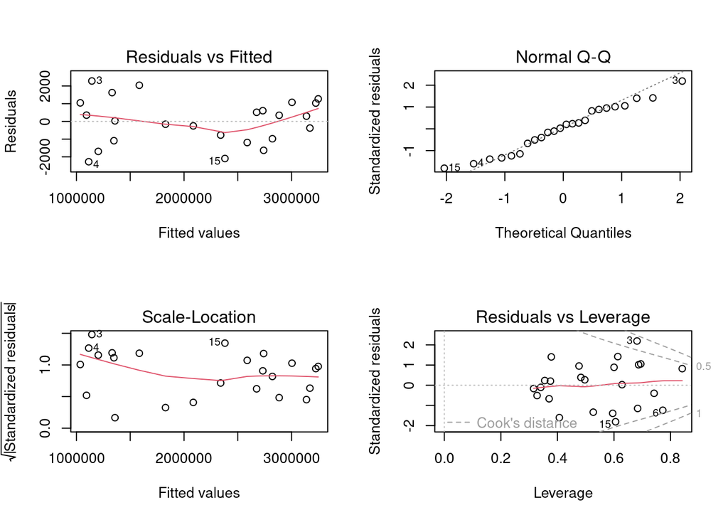

```r
plot(av)
```

### Testando a Normalidade

Anderson-Darling normality test

```r
anares<-rstandard(mod)
library(nortest)
ad.test(anares)
```

```
##
##  Anderson-Darling normality test
##
## data:  anares
## A = 0.26968, p-value = 0.6473
```

Shapiro-Wilk normality test

```r
shapiro.test(anares)
```

```
##
##  Shapiro-Wilk normality test
##
## data:  anares
## W = 0.96907, p-value = 0.6441
```

### Testando a Homocedasticidade

A estatística de teste é **18,693** e o valor p correspondente é **0,0962**. Como o valor de p não é menor que 0,05, não rejeitamos a hipótese nula. Não temos evidências suficientes para dizer que a heterocedasticidade está presente no modelo de regressão.

```r
library(zoo)
library(lmtest)
bptest(mod)
```

```
##
##  studentized Breusch-Pagan test
##
## data:  mod
## BP = 18.693, df = 12, p-value = 0.0962
```

### Testando a Autocorrelação

A partir da saída, podemos ver que a estatística de teste é **1,8275** e o valor p correspondente é **0,01281**. Como esse valor de p é menor que 0,05, podemos rejeitar a hipótese nula e concluir que os resíduos nesse modelo de regressão são autocorrelacionados.

```r
dwtest(mod)
```

```
##
##  Durbin-Watson test
##
## data:  mod
## DW = 1.8275, p-value = 0.01281
## alternative hypothesis: true autocorrelation is greater than 0
```

# Intervalo de confiança

Como o ajuste não foi passou por todos os pressupostos, significa que o modelo não fará uma previsão confiável, porém, segue uma simulação de previsão e intervalo de confiança.

```r
pred_in = data.frame(
  BALGR=-38417.8,
  REII=131508.8,
  VALU=1644856.5,
  FFD_DVA=385330.4,
  DFD_FVA=423748.1,
  CONS_VA=1268617.6,
  EXGR_SERV_FVASH=11.64,
  IMGRINT_REII=41.17,
  IMGR_DVASH=0.942,
  VALU_FFDDVA=23.43,
  PROD_VASH=54.74,
  FEXDVAPSH=14.648
)

predict(mod, pred_in, interval="confidence")
```

```
##       fit     lwr     upr
## 1 3003739 3000356 3007121
```